# regression model diagnostics

Alejandra Garcia Isaza

2022-07-19

```r
d <- read_sav(here("outcomes paper/data_outcomes", "p_y_w1_for_analysesjan25.sav"))

d1 <- d %>%
  mutate(parent_eng_comf = as.numeric(parent_eng_comf),
         youth_gender = as.numeric(youth_gender),
         youth_age = as.numeric(youth_age))
```

# Model assumptions & diagnostics

Multiple Regression models have the following assumptions: 1. Linearity (rel between X and Y is linear) 2. Independence of errors (residuals are not correlated) 3. Homoscedasticity (constant variance of residuals) 4. Normality of Residuals (residuals follow a normal distribution) 5. No multicollinearity (predictors not too correlated) 6. No ommited variable variable bias (all relevant variables are included)

Note: The normality assumption in multiple regression applies to the residuals, not the observed variables (predictors or outcome).

#### Select variables of interest

```r
vars_of_interest <- d1[, c("parent_eng_comf", "youth_gender", "youth_age", "acadhwi_1", "checkhwi_1", "struct_1", "convfut_1", "knowschool_1", "parnets_1", "welcome_1", "endorse_1", "supported_1", "ptrel_1", "y_sch_eng", "y_parsupp", "y_parinv", "y_hw", "grades", "gen_grades", "selfeffic_1")]
```

#### Convert to long format for ggplot

```r
long_data <- pivot_longer(vars_of_interest, cols = everything(), names_to = "Variable", values_to = "Value")
```

#### Plot histograms

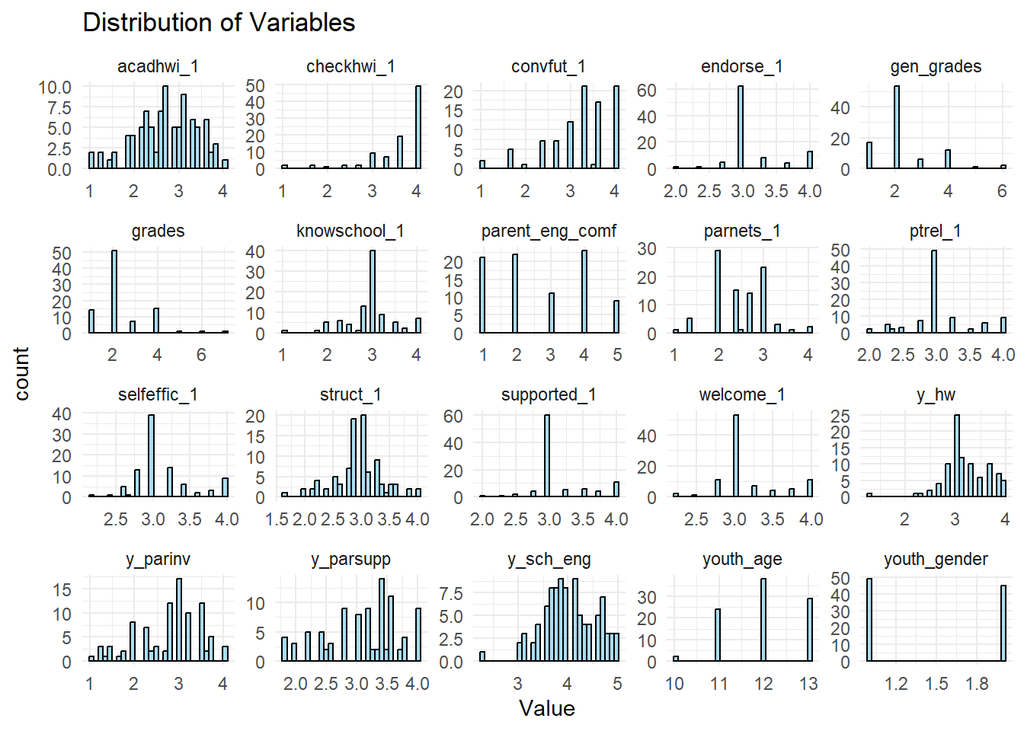

```r
ggplot(long_data, aes(x = Value)) +
  geom_histogram(bins = 30, fill = "skyblue", color = "black", alpha = 0.7) +
  facet_wrap(~ Variable, scales = "free") +  # One plot per variable
  theme_minimal() +
  labs(title = "Distribution of Variables")
```

## linearity

#### Plot residuals vs. fitted values

Result: with and without youth gender linearity is likely met for youth school engagement

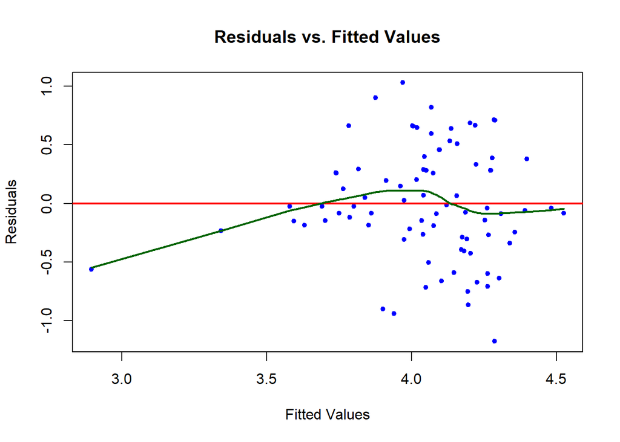

```r
model <- lm(y_sch_eng ~ parent_eng_comf + youth_age + youth_gender + acadhwi_1 + checkhwi_1 + struct_1 + convfut_1 + knowschool_1 + parnets_1 + welcome_1 + endorse_1 + supported_1 + ptrel_1, vars_of_interest)

plot(fitted(model), residuals(model),
     main = "Residuals vs. Fitted Values",
     xlab = "Fitted Values", ylab = "Residuals",
     pch = 20, col = "blue")
abline(h = 0, col = "red", lwd = 2)  # Add reference line at 0

lines(lowess(fitted(model), residuals(model)), col = "darkgreen", lwd = 2)
```

Result: with and without youth gender linearity is likely met for youth hw practices

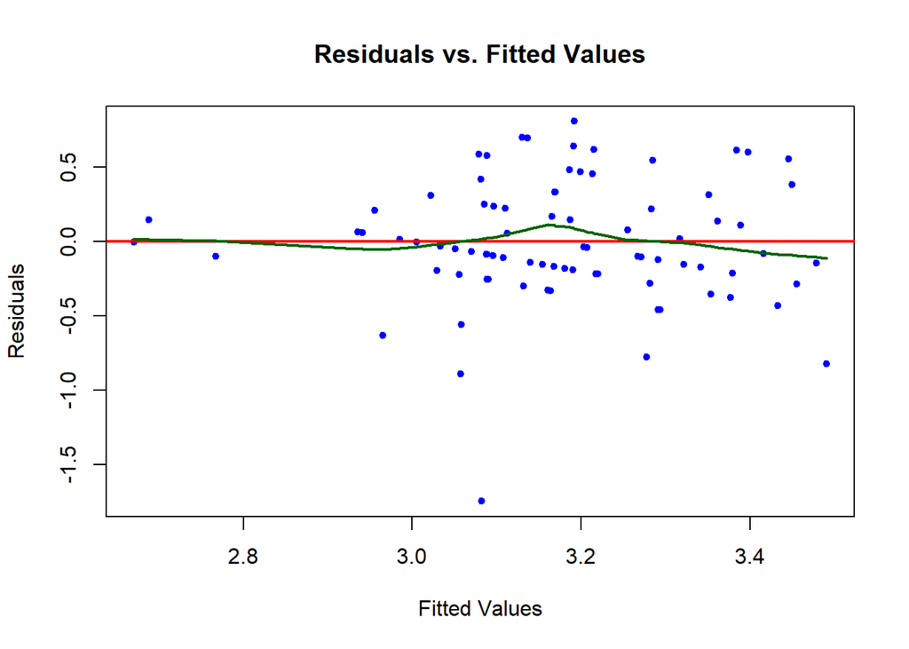

```r
model <- lm(y_hw ~ parent_eng_comf + youth_age + youth_gender + acadhwi_1 + checkhwi_1 + struct_1 + convfut_1 + knowschool_1 + parnets_1 + welcome_1 + endorse_1 + supported_1 + ptrel_1, vars_of_interest)

plot(fitted(model), residuals(model),
     main = "Residuals vs. Fitted Values",
     xlab = "Fitted Values", ylab = "Residuals",
     pch = 20, col = "blue")
abline(h = 0, col = "red", lwd = 2)  # Add reference line at 0

lines(lowess(fitted(model), residuals(model)), col = "darkgreen", lwd = 2)
```

Result: with and without youth gender linearity is likely met for youth-reported parent support

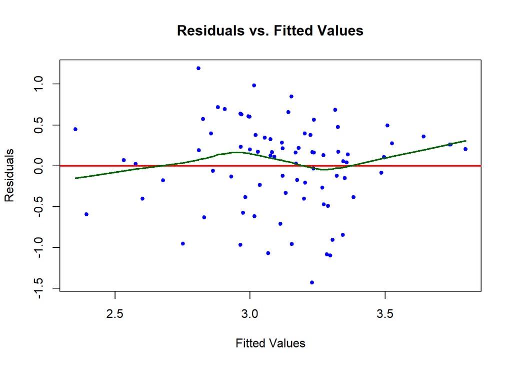

```r
model <- lm(y_parsupp ~ parent_eng_comf + youth_age + youth_gender + acadhwi_1 + checkhwi_1 + struct_1 + convfut_1 + knowschool_1 + parnets_1 + welcome_1 + endorse_1 + supported_1 + ptrel_1, vars_of_interest)

plot(fitted(model), residuals(model),
     main = "Residuals vs. Fitted Values",
     xlab = "Fitted Values", ylab = "Residuals",
     pch = 20, col = "blue")
abline(h = 0, col = "red", lwd = 2)  # Add reference line at 0

lines(lowess(fitted(model), residuals(model)), col = "darkgreen", lwd = 2)
```

Result: with and without youth gender linearity is likely met for youth-reported parent involvement

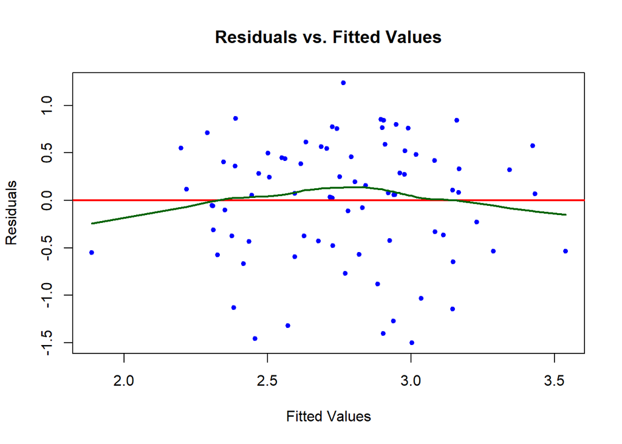

```r
model <- lm(y_parinv ~ parent_eng_comf + youth_age + youth_gender + acadhwi_1 + checkhwi_1 + struct_1 + convfut_1 + knowschool_1 + parnets_1 + welcome_1 + endorse_1 + supported_1 + ptrel_1, vars_of_interest)

plot(fitted(model), residuals(model),
     main = "Residuals vs. Fitted Values",
     xlab = "Fitted Values", ylab = "Residuals",
     pch = 20, col = "blue")
abline(h = 0, col = "red", lwd = 2)  # Add reference line at 0

lines(lowess(fitted(model), residuals(model)), col = "darkgreen", lwd = 2)
```

Youth reported grades Result: with and without youth gender the point look similar. Not sure if linearity is met because it has kind of a pattern, but it’s not a curved one.

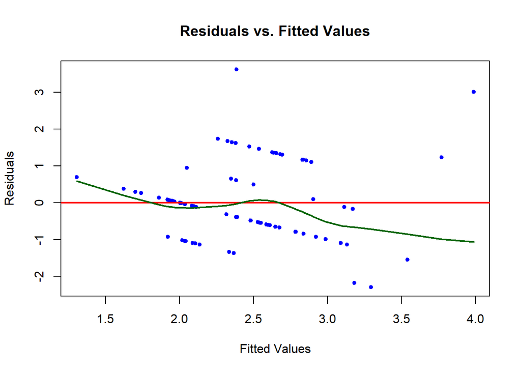

```r
model <- lm(grades ~ parent_eng_comf + youth_age + youth_gender + acadhwi_1 + checkhwi_1 + struct_1 + convfut_1 + knowschool_1 + parnets_1 + welcome_1 + endorse_1 + supported_1 + ptrel_1, vars_of_interest)

plot(fitted(model), residuals(model),
     main = "Residuals vs. Fitted Values",
     xlab = "Fitted Values", ylab = "Residuals",
     pch = 20, col = "blue")
abline(h = 0, col = "red", lwd = 2)  # Add reference line at 0

lines(lowess(fitted(model), residuals(model)), col = "darkgreen", lwd = 2)
```

Parent reported grades Result: with and without youth gender the point look similar. Not sure if linearity is met because it has kind of a pattern, but it’s not a curved one.

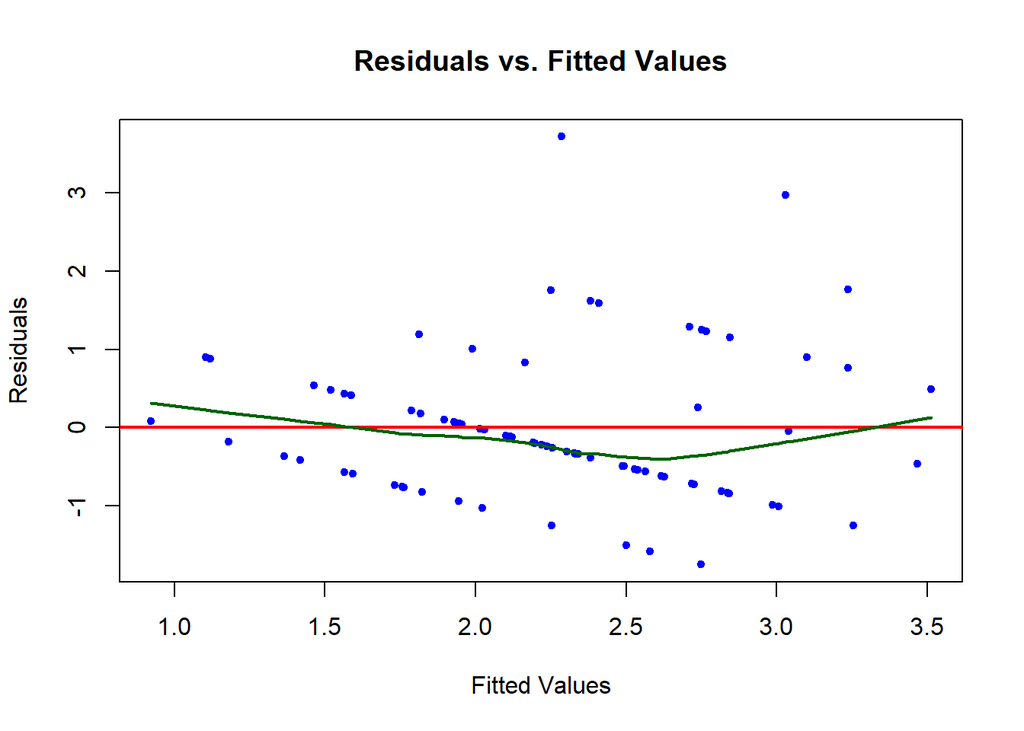

```r
model <- lm(gen_grades ~ parent_eng_comf + youth_age + youth_gender + acadhwi_1 + checkhwi_1 + struct_1 + convfut_1 + knowschool_1 + parnets_1 + welcome_1 + endorse_1 + supported_1 + ptrel_1, vars_of_interest)

plot(fitted(model), residuals(model),
     main = "Residuals vs. Fitted Values",
     xlab = "Fitted Values", ylab = "Residuals",
     pch = 20, col = "blue")
abline(h = 0, col = "red", lwd = 2)  # Add reference line at 0

lines(lowess(fitted(model), residuals(model)), col = "darkgreen", lwd = 2)
```

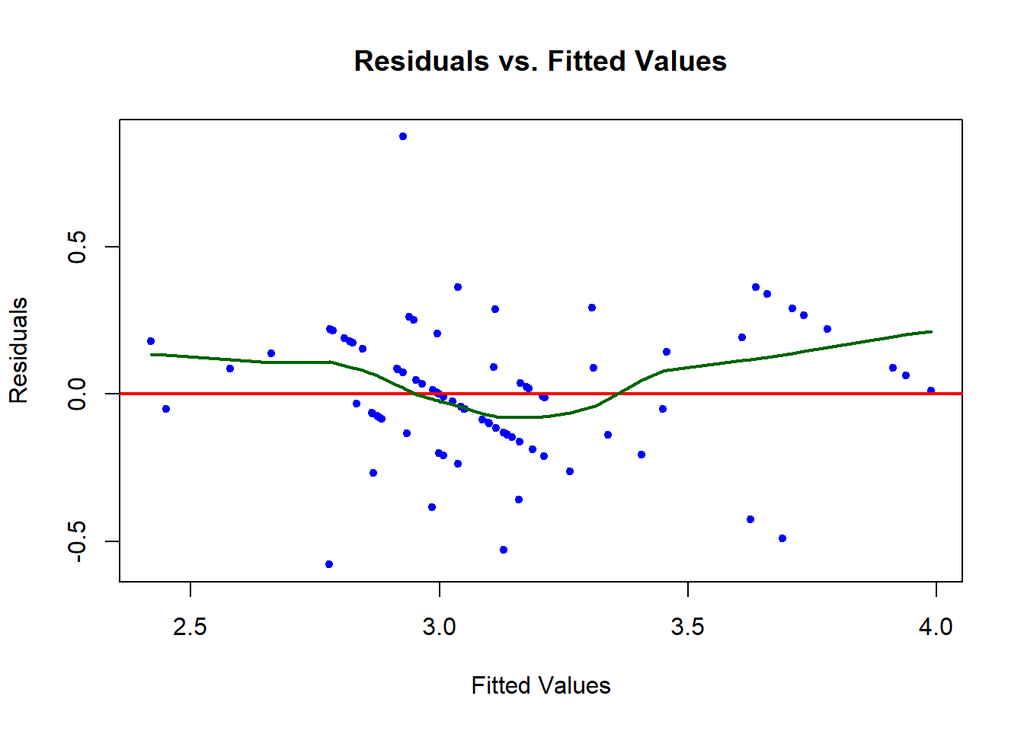

```r
model <- lm(selfeffic_1  ~ parent_eng_comf + youth_age + youth_gender + acadhwi_1 + checkhwi_1 + struct_1 + convfut_1 + knowschool_1 + parnets_1 + welcome_1 + endorse_1 + supported_1 + ptrel_1, vars_of_interest)

plot(fitted(model), residuals(model),
     main = "Residuals vs. Fitted Values",
     xlab = "Fitted Values", ylab = "Residuals",
     pch = 20, col = "blue")
abline(h = 0, col = "red", lwd = 2)  # Add reference line at 0

lines(lowess(fitted(model), residuals(model)), col = "darkgreen", lwd = 2)
```

## Independence of errors

#### Durbin-Watson test

- ~2.0 → No autocorrelation (Good)
- < 1.5 → Positive autocorrelation (Bad)
- > 2.5 → Negative autocorrelation (Less common but also bad)

Results: lowest is 1.83 and highest is 2.3; hence residuals are reasonably independent across models.

## Homoscedasticity

None of the residual vs. fitted values plots above show a funnel shape #### Fit regression model #### Breusch-Pagan Test (Statistical Test) p > 0.05 → Homoscedasticity (Good) p < 0.05 → Heteroscedasticity (Bad)

Results: p-values in each of the 7 models are p > 0.05 → Homoscedasticity

```r
model <- lm(y_sch_eng ~ parent_eng_comf + youth_age + youth_gender + acadhwi_1 + checkhwi_1 + struct_1 + convfut_1 + knowschool_1 + parnets_1 + welcome_1 + endorse_1 + supported_1 + ptrel_1, vars_of_interest)
durbinWatsonTest(model) # for independence of errors
```

```
##  lag Autocorrelation D-W Statistic p-value
##    1     -0.02714089       2.04274    0.82
##  Alternative hypothesis: rho != 0
```

```r
bptest(model) # for homoscedasticity
```

```
##
##  studentized Breusch-Pagan test
##
## data:  model
## BP = 17.751, df = 13, p-value = 0.1672
```

```r
model <- lm(y_hw ~ parent_eng_comf + youth_age + youth_gender + acadhwi_1 + checkhwi_1 + struct_1 + convfut_1 + knowschool_1 + parnets_1 + welcome_1 + endorse_1 + supported_1 + ptrel_1, vars_of_interest)
durbinWatsonTest(model) # for independence of errors
```

```
##  lag Autocorrelation D-W Statistic p-value
##    1      -0.1439185      2.269068   0.214
##  Alternative hypothesis: rho != 0
```

```r
bptest(model) # for homoscedasticity
```

```
##
##  studentized Breusch-Pagan test
##
## data:  model
## BP = 9.1312, df = 13, p-value = 0.763
```

```r
model <- lm(y_parsupp ~ parent_eng_comf + youth_age + youth_gender + acadhwi_1 + checkhwi_1 + struct_1 + convfut_1 + knowschool_1 + parnets_1 + welcome_1 + endorse_1 + supported_1 + ptrel_1, vars_of_interest)
durbinWatsonTest(model) # for independence of errors
```

```
##  lag Autocorrelation D-W Statistic p-value
##    1      -0.1285043      2.253767    0.23
##  Alternative hypothesis: rho != 0
```

```r
bptest(model) # for homoscedasticity
```

```
##
##  studentized Breusch-Pagan test
##
## data:  model
## BP = 9.6394, df = 13, p-value = 0.7231
```

```r
model <- lm(y_parinv ~ parent_eng_comf + youth_age + youth_gender + acadhwi_1 + checkhwi_1 + struct_1 + convfut_1 + knowschool_1 + parnets_1 + welcome_1 + endorse_1 + supported_1 + ptrel_1, vars_of_interest)
durbinWatsonTest(model) # for independence of errors
```

```
##  lag Autocorrelation D-W Statistic p-value
##    1      0.06673467      1.833465   0.428
##  Alternative hypothesis: rho != 0
```

```r
bptest(model) # for homoscedasticity
```

```
##
##  studentized Breusch-Pagan test
##
## data:  model
## BP = 5.6233, df = 13, p-value = 0.9588
```

```r
model <- lm(grades ~ parent_eng_comf + youth_age + youth_gender + acadhwi_1 + checkhwi_1 + struct_1 + convfut_1 + knowschool_1 + parnets_1 + welcome_1 + endorse_1 + supported_1 + ptrel_1, vars_of_interest)
durbinWatsonTest(model) # for independence of errors
```

```
##  lag Autocorrelation D-W Statistic p-value
##    1      0.01485839      1.948434   0.794
##  Alternative hypothesis: rho != 0
```

```r
bptest(model) # for homoscedasticity
```

```
##
##  studentized Breusch-Pagan test
##
## data:  model
## BP = 17.291, df = 13, p-value = 0.1863
```

```r
model <- lm(gen_grades ~ parent_eng_comf + youth_age + youth_gender + acadhwi_1 + checkhwi_1 + struct_1 + convfut_1 + knowschool_1 + parnets_1 + welcome_1 + endorse_1 + supported_1 + ptrel_1, vars_of_interest)
durbinWatsonTest(model) # for independence of errors
```

```
##  lag Autocorrelation D-W Statistic p-value
##    1    -0.007084846      2.005587   0.992
##  Alternative hypothesis: rho != 0
```

```r
bptest(model) # for homoscedasticity
```

```
##
##  studentized Breusch-Pagan test
##
## data:  model
## BP = 8.3053, df = 13, p-value = 0.8232
```

```r
model <- lm(selfeffic_1 ~ parent_eng_comf + youth_age + youth_gender + acadhwi_1 + checkhwi_1 + struct_1 + convfut_1 + knowschool_1 + parnets_1 + welcome_1 + endorse_1 + supported_1 + ptrel_1, vars_of_interest)
durbinWatsonTest(model) # for independence of errors
```

```
##  lag Autocorrelation D-W Statistic p-value
##    1      0.01550748      1.947564    0.83
##  Alternative hypothesis: rho != 0
```

```r
bptest(model) # for homoscedasticity
```

```
##
##  studentized Breusch-Pagan test
##
## data:  model
## BP = 13.084, df = 13, p-value = 0.4413
```